# Covid-19 - SMSD

#### Goal

Build up a useful model in order to predict response variable Y starting from data provided.

- response variable: number of new positives
- data: Covid-19 spreading outbreak from the official website of Protezione Civile

#### Dataset

Load dataset.

Read data we are interested in, then those that are relative to the following couple of parameters:

- regione: Sicilia
- data: 1st October 2020 to 1st February 2021

#### Quality of the data

Check for missing values in the data frame

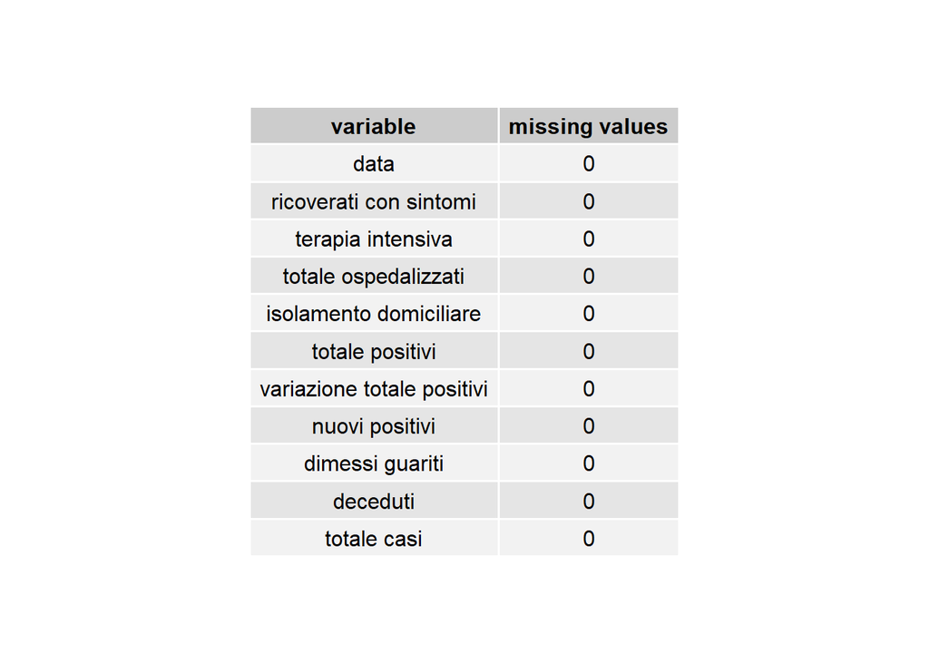

#### Clean dataset

Get rid of redundant and not useful variables, substitute or replace missing values and finally check for any kinf of relationship between variables.

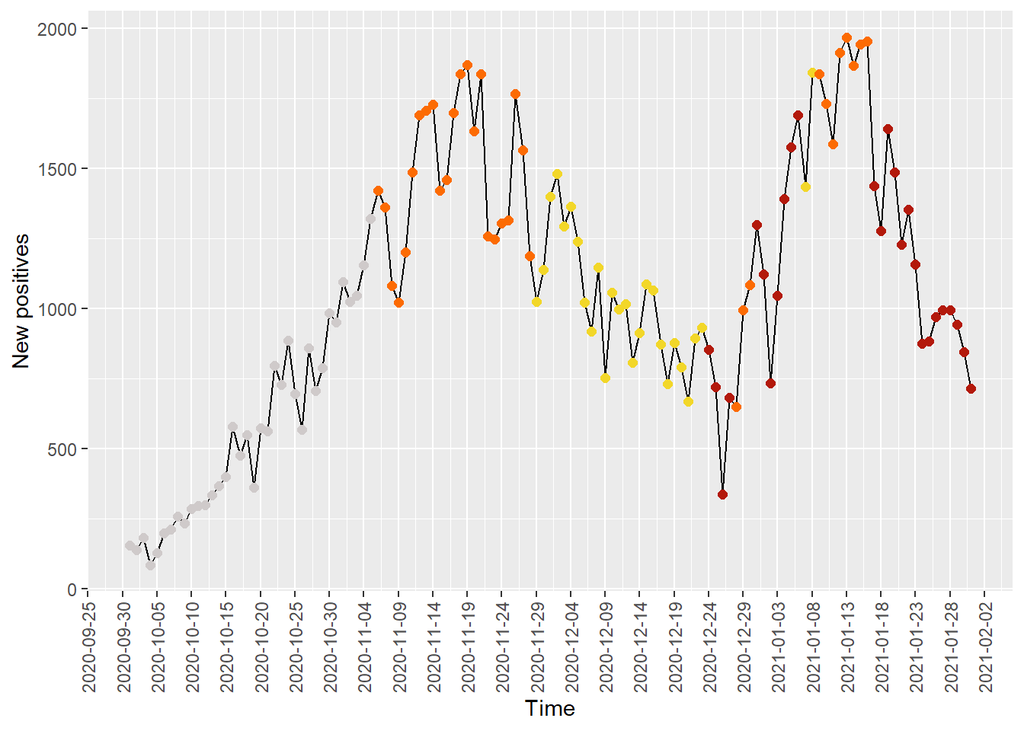

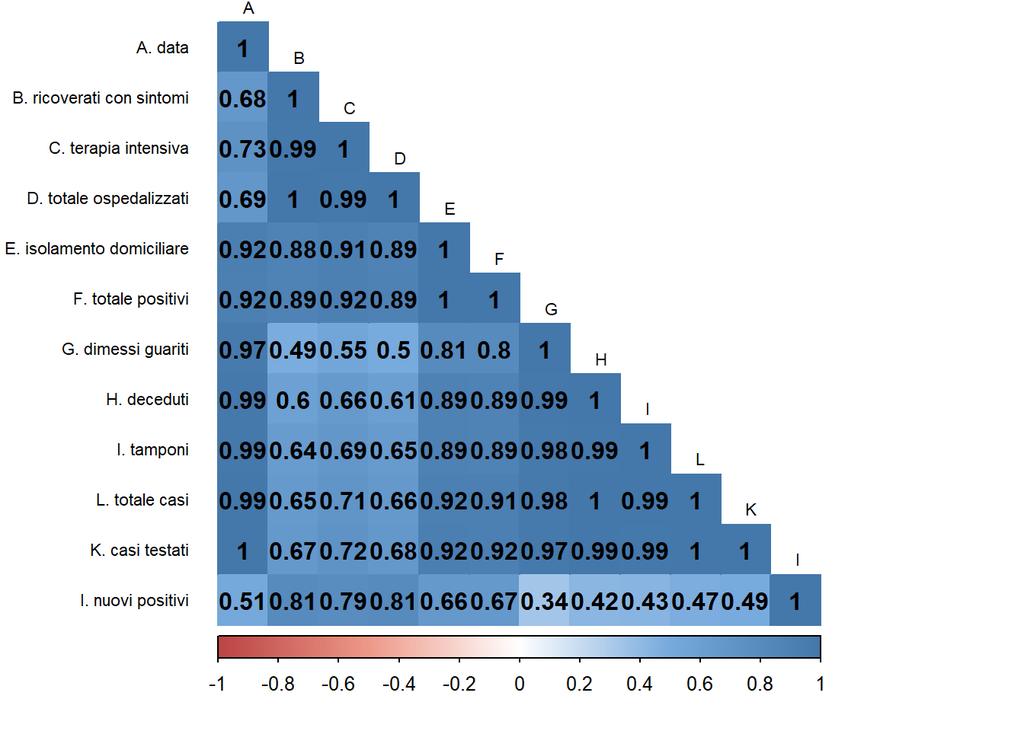

We can see there are many variables which are highly related, though this relationship can be due to the fact that they are not independent. While for others variables we observe a poor correlation while we would have expected something different, for example for the number of swabs carried out. For this reason new variables were introduced for those values which account for the total amount of cases since the beginning of the pandemic.

- nuovi_tamponi: swabs carried out daily (tamponi current day - tamponi predious day) [by the 15/01 were counted also the antigenic tests]
- nuovi_decessi: daily deaths (deceduti current day - deceduti previous day)

#### Perform some explanatory analysis of the data

Then a new correlation plot is made to show which are the most highly correlated variables.

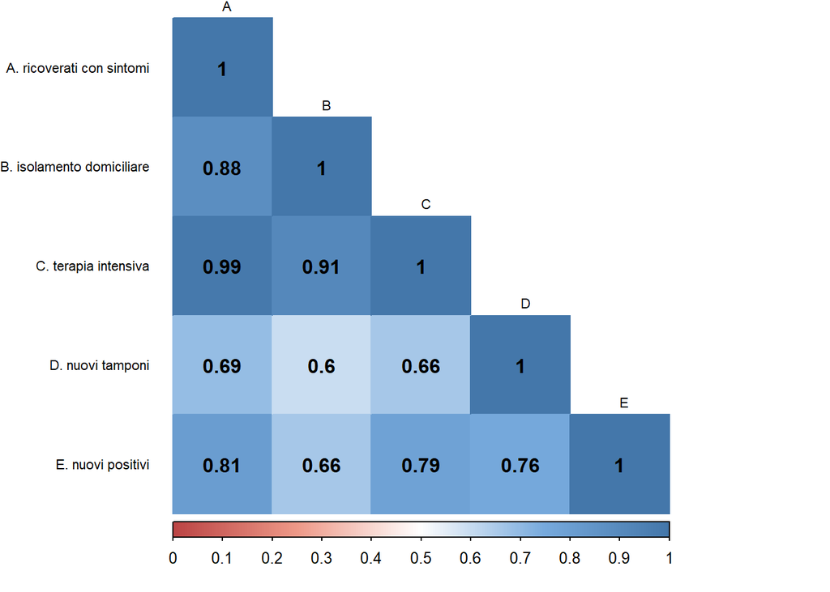

Further investigate the correlations found between each pair of variables

The following plot shows the trends of previous variable through all the time period considered, it can be seen how it is almost the same for each of them, exept for the number of swabs.

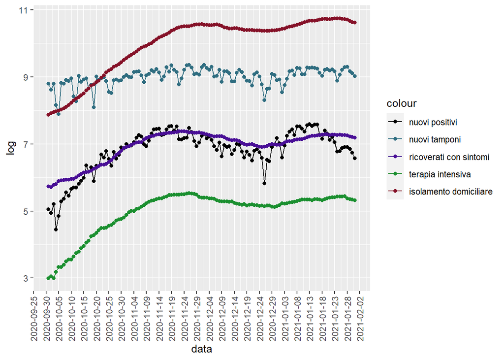

Previous chosen covariates were part of the given dataset, now we investigate possible relationships with information which is not part of our dataset. The first covariate which has been considered and added is related to the restrictions to which the region considered was subjected in the period considered. These restrictions are of 4 different levels, which are the 4 possible regional colors: white, yellow, orange, red.

- See how response variable changes wrt to region colors:

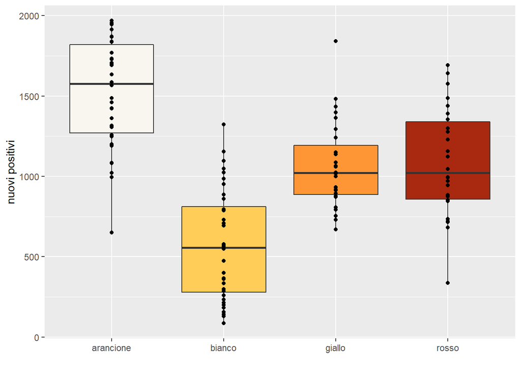

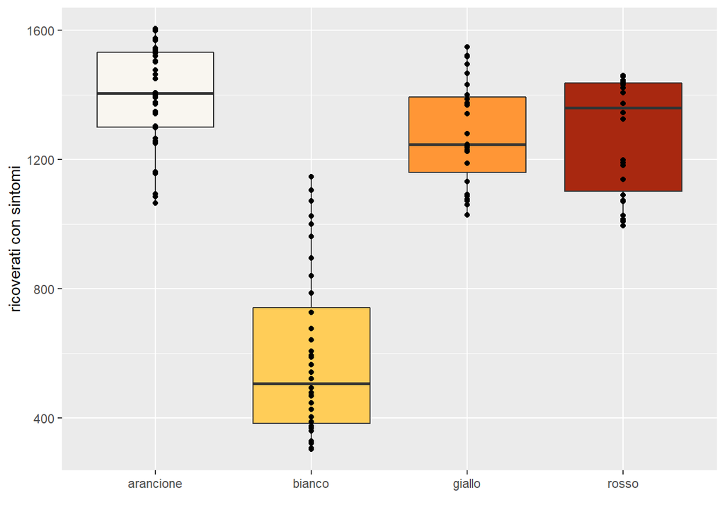

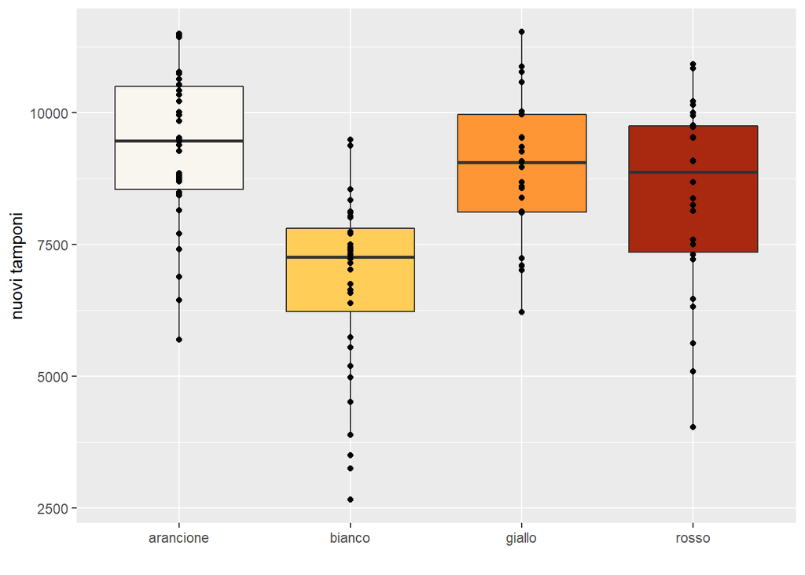

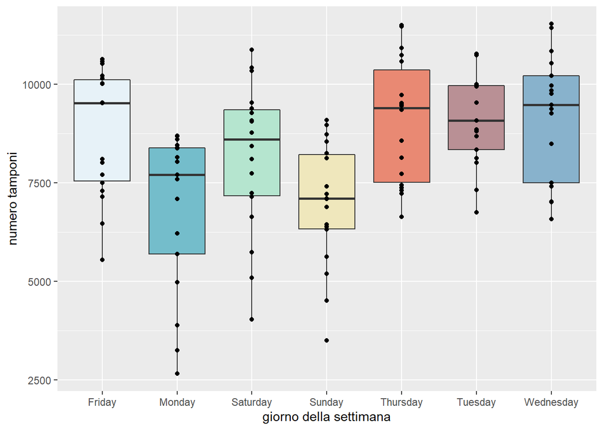

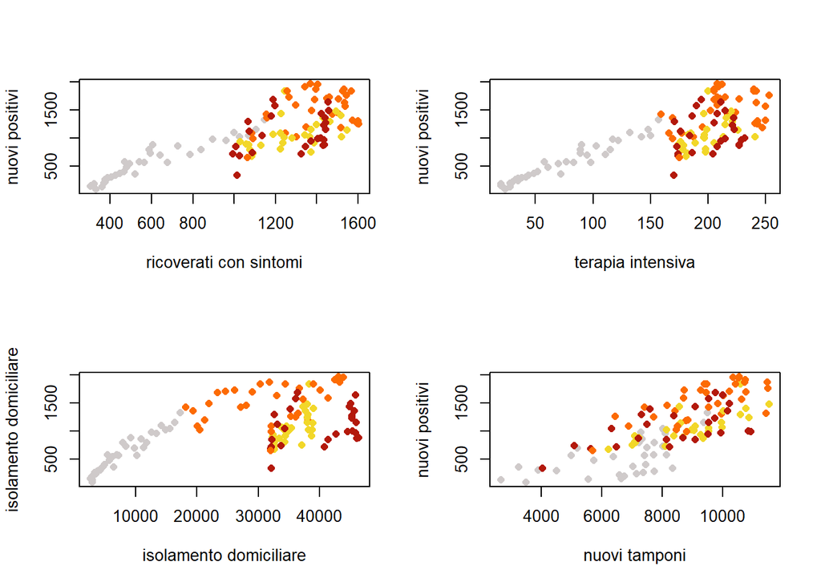

## Building models

We start building our model looking at the relationship between our response variable and its highest correlated predictor (which is given by people hospitalized with symptoms, maybe because the highest the number of people hospitalized, the higher the contagiousness and as a consequence the higher the number of new positives).

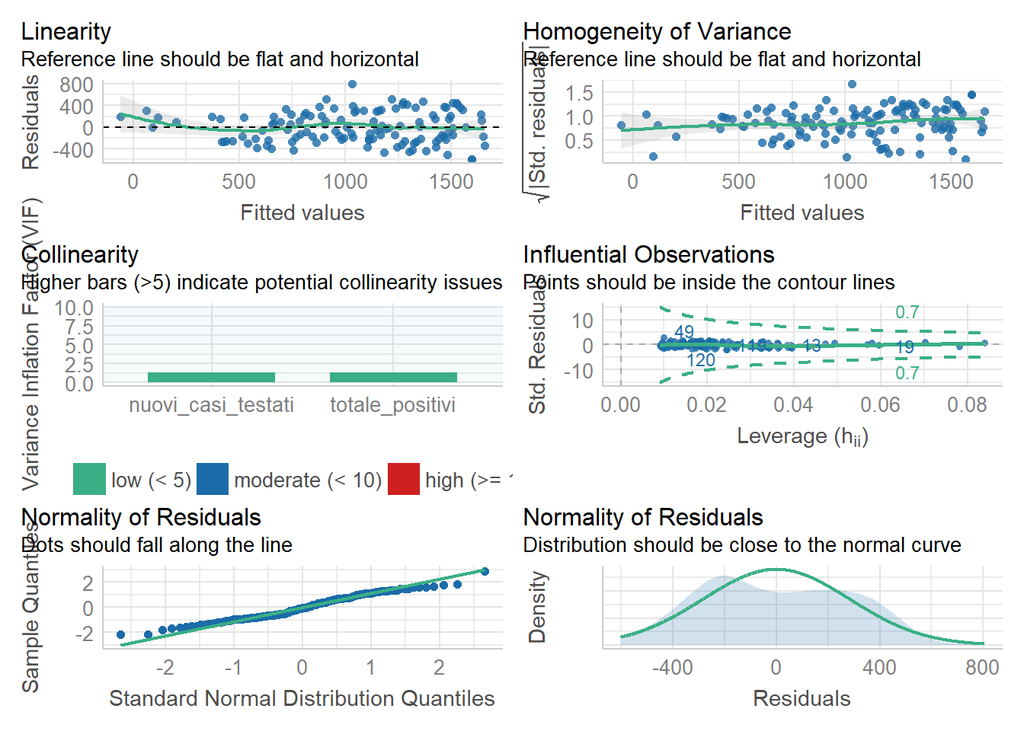

```r
library(performance)
library(see)
new1 <- lm(nuovi_positivi ~ nuovi_casi_testati + totale_positivi , data=df)
new2 <- lm(nuovi_positivi ~ nuovi_casi_testati + totale_positivi + color , data=df)
old2 <- lm(nuovi_positivi ~ nuovi_tamponi_pcr + ricoverati_con_sintomi + color, data=df)
new3 <- glm(nuovi_positivi ~ nuovi_casi_testati + totale_positivi, data=df, family = poisson())

check_model(new1)
```

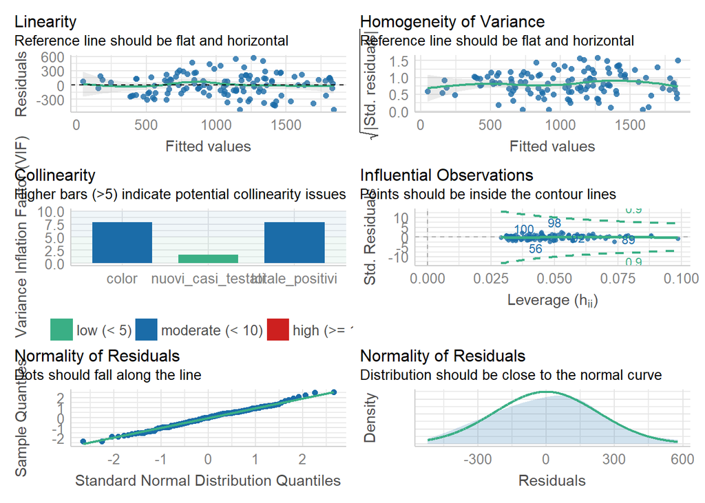

```r
check_model(new2)
```

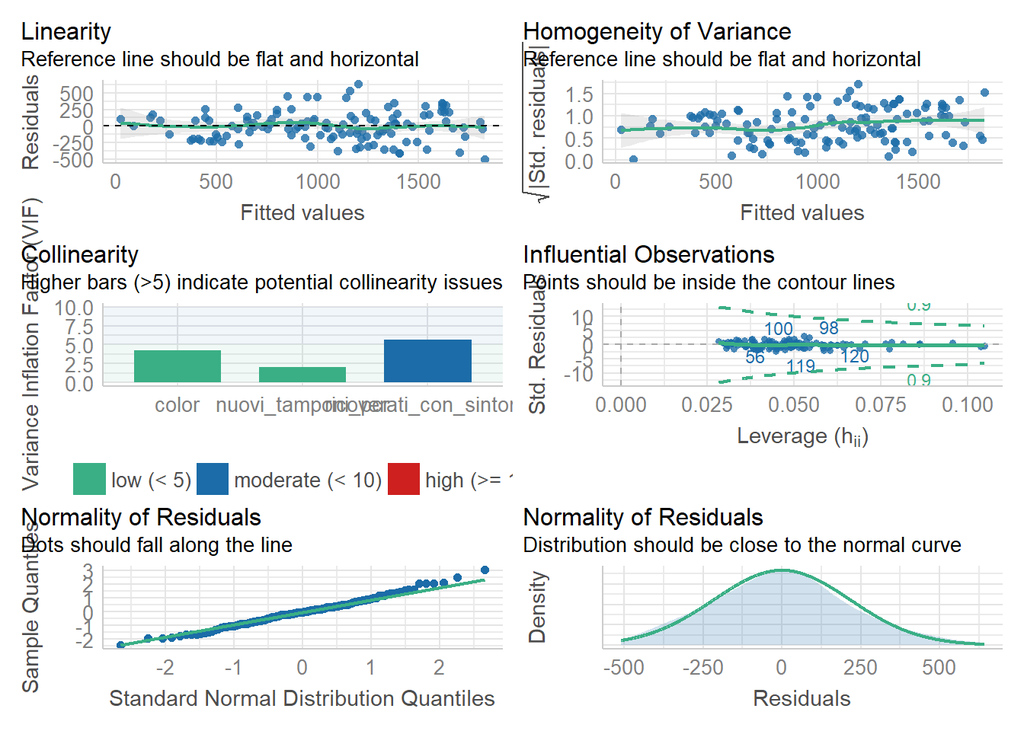

```r
check_model(old2)
```

```r
compare_performance(new1,new2, old2, rank= TRUE)
```

```
## # Comparison of Model Performance Indices
##
## Name | Model |    R2 | R2 (adj.) |    RMSE |   Sigma | AIC weights | BIC weights | Performance-Score
## ----------------------------------------------------------------------------------------------------
## old2 |    lm | 0.798 |     0.789 | 216.700 | 222.187 |       0.998 |       0.998 |           100.00%
## new2 |    lm | 0.777 |     0.767 | 227.758 | 233.525 |       0.002 |       0.002 |            56.22%
## new1 |    lm | 0.651 |     0.645 | 284.747 | 288.284 |     < 0.001 |     < 0.001 |             0.00%
```

### Linear models

```
##
## Call:
## lm(formula = eval(formula[3]), data = df)
##
## Residuals:
##     Min      1Q  Median      3Q     Max
## -601.41 -146.32  -15.46  140.34  807.22
##
## Coefficients:
##                                      Estimate Std. Error t value Pr(>|t|)
## (Intercept)                         395.73880  391.95759   1.010  0.31478
## ricoverati_con_sintomi                0.80420    0.27880   2.885  0.00468 **
## colorbianco                        -587.72826  406.65205  -1.445  0.15110
## colorgiallo                        -412.50003  563.44828  -0.732  0.46560
## colorrosso                         -209.92754  541.91381  -0.387  0.69919
## ricoverati_con_sintomi:colorbianco    0.46828    0.32547   1.439  0.15293
## ricoverati_con_sintomi:colorgiallo    0.03973    0.41934   0.095  0.92469
## ricoverati_con_sintomi:colorrosso    -0.09956    0.40224  -0.248  0.80494
## ---
## Signif. codes:  0 '***' 0.001 '**' 0.01 '*' 0.05 '.' 0.1 ' ' 1
##
## Residual standard error: 254.1 on 115 degrees of freedom
## Multiple R-squared:  0.7401, Adjusted R-squared:  0.7243
## F-statistic: 46.78 on 7 and 115 DF,  p-value: < 2.2e-16
```

```
##
## Call:
## lm(formula = eval(formula[5]), data = df)
##
## Residuals:
##     Min      1Q  Median      3Q     Max
## -583.67 -101.91  -21.17  116.30  564.25
##
## Coefficients:
##                                      Estimate Std. Error t value Pr(>|t|)
## (Intercept)                        -395.61872  340.31644  -1.163 0.247525
## ricoverati_con_sintomi                0.33827    0.23606   1.433 0.154675
## nuovi_tamponi_pcr                     0.15428    0.02618   5.894 4.12e-08 ***
## colorbianco                          67.17367  369.81277   0.182 0.856195
## colorgiallo                         -92.95396  483.12168  -0.192 0.847778
## colorrosso                          794.78225  455.69555   1.744 0.083909 .
## ricoverati_con_sintomi:colorbianco    0.83002    0.28554   2.907 0.004409 **
## ricoverati_con_sintomi:colorgiallo   -0.06521    0.37101  -0.176 0.860807
## ricoverati_con_sintomi:colorrosso    -0.71834    0.42331  -1.697 0.092503 .
## nuovi_tamponi_pcr:colorbianco        -0.12507    0.03609  -3.465 0.000755 ***
## nuovi_tamponi_pcr:colorgiallo        -0.01958    0.04207  -0.465 0.642594
## nuovi_tamponi_pcr:colorrosso         -0.01487    0.04290  -0.347 0.729619
## ---
## Signif. codes:  0 '***' 0.001 '**' 0.01 '*' 0.05 '.' 0.1 ' ' 1
##
## Residual standard error: 202.8 on 111 degrees of freedom
## Multiple R-squared:  0.8403, Adjusted R-squared:  0.8245
## F-statistic: 53.11 on 11 and 111 DF,  p-value: < 2.2e-16
```

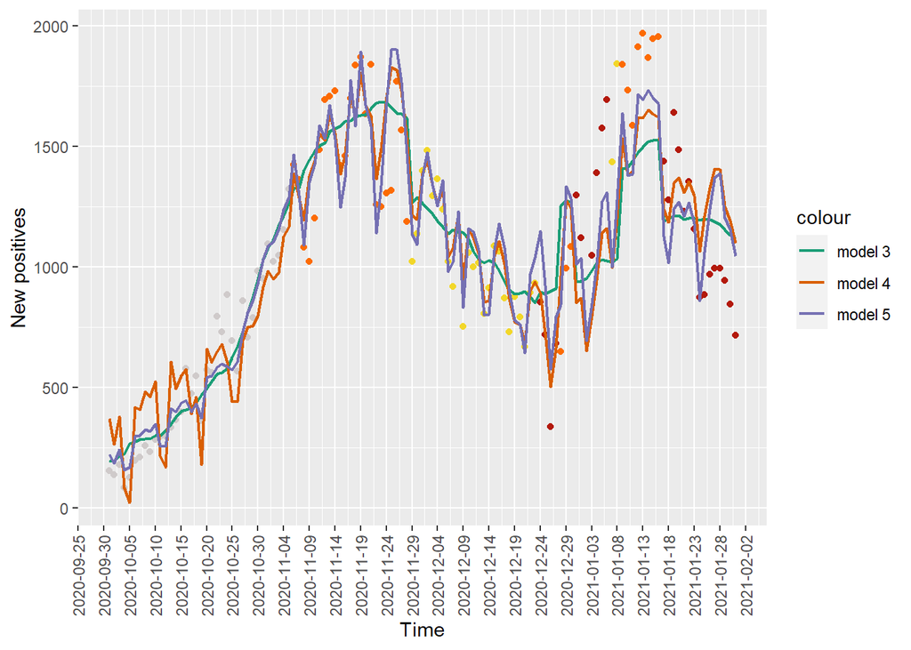

Moltiplicare per il colore invece di sommare fa si che cambi l’inclinazione della retta.

### Generalized linear models

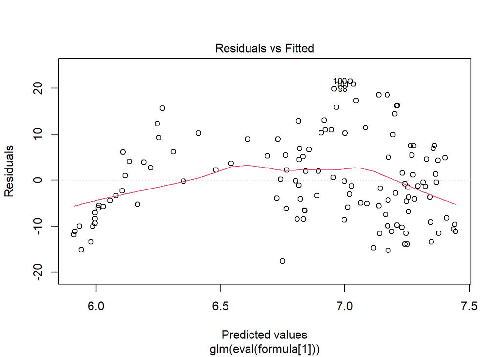

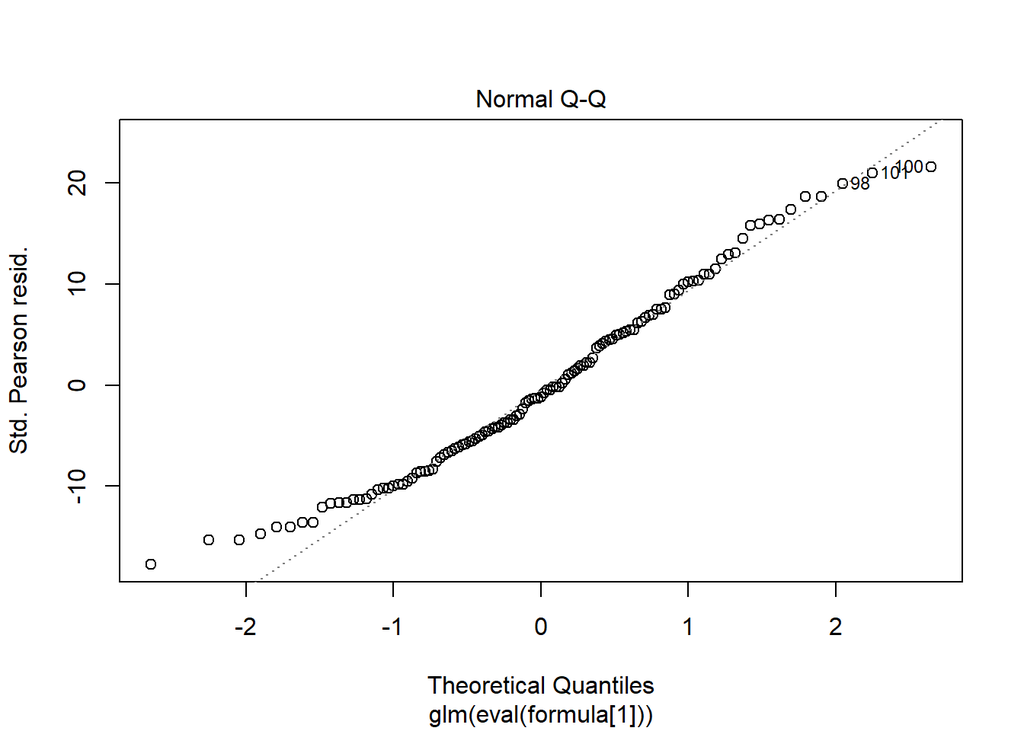

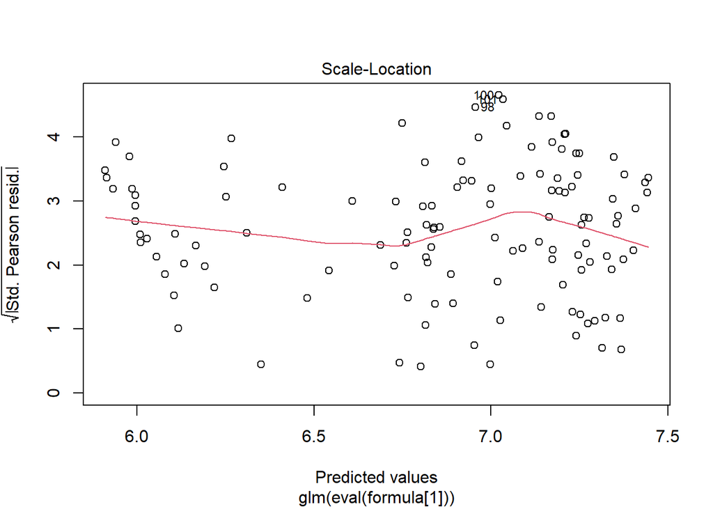

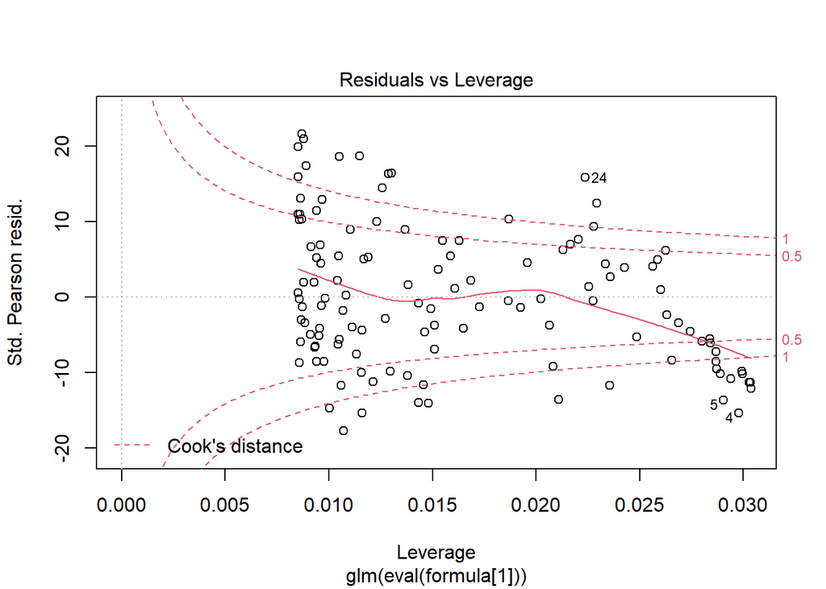

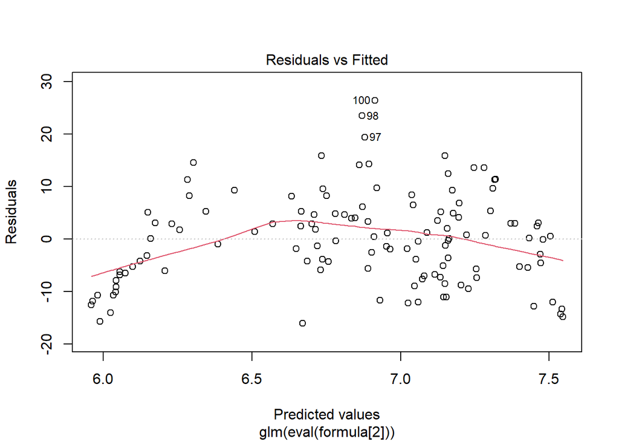

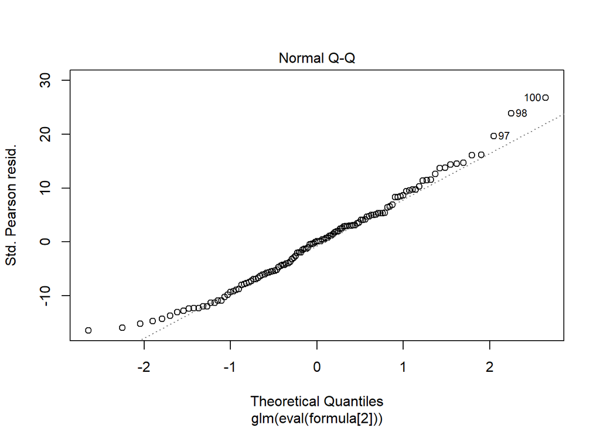

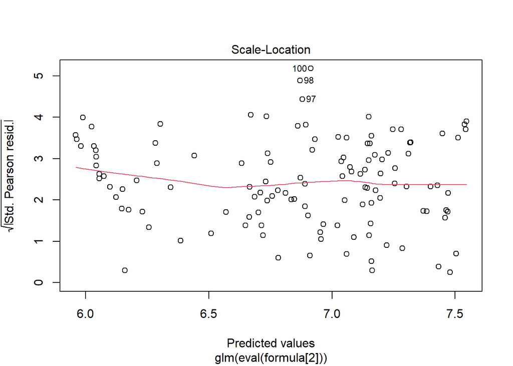

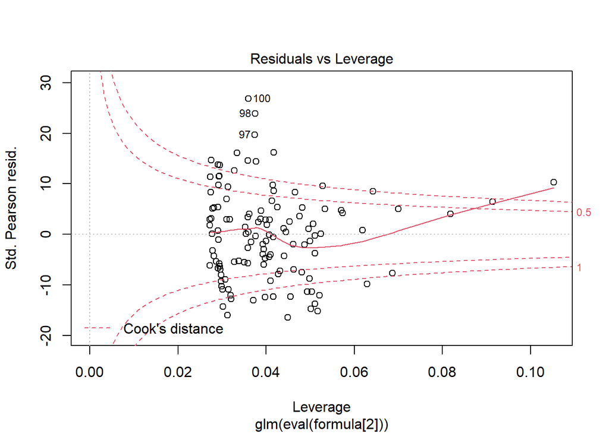

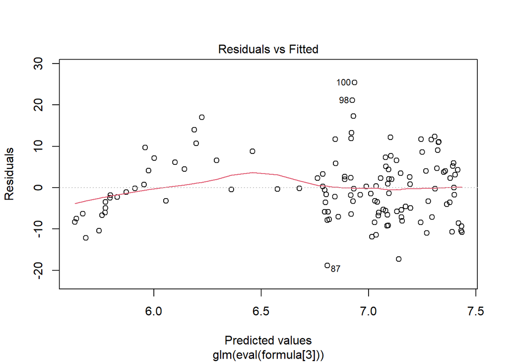

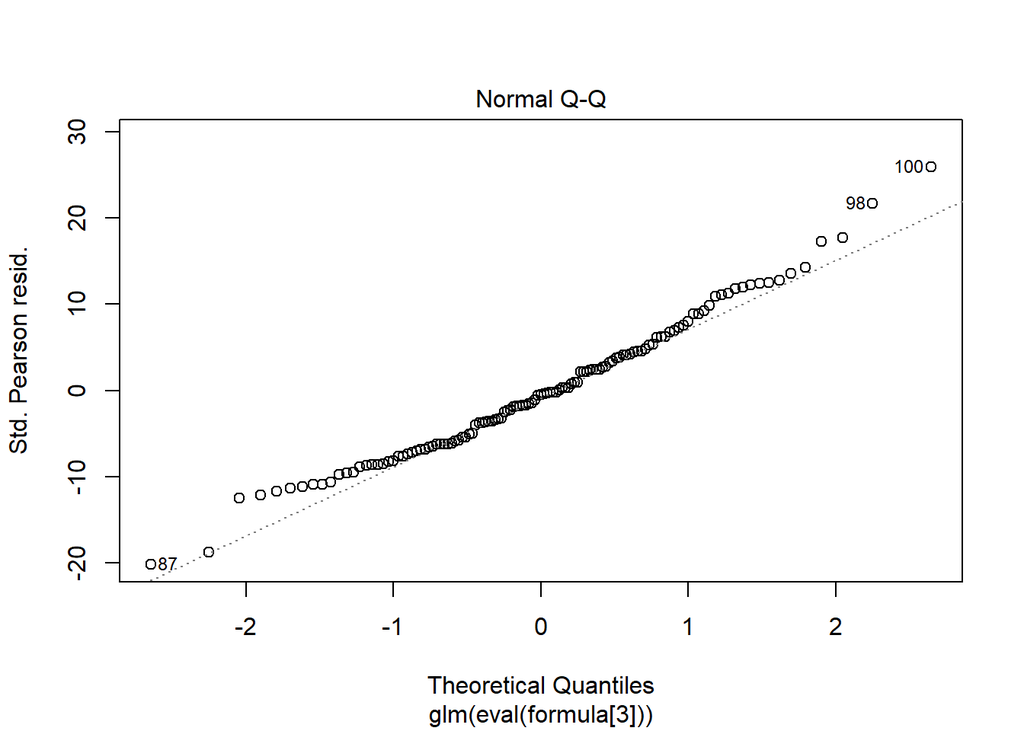

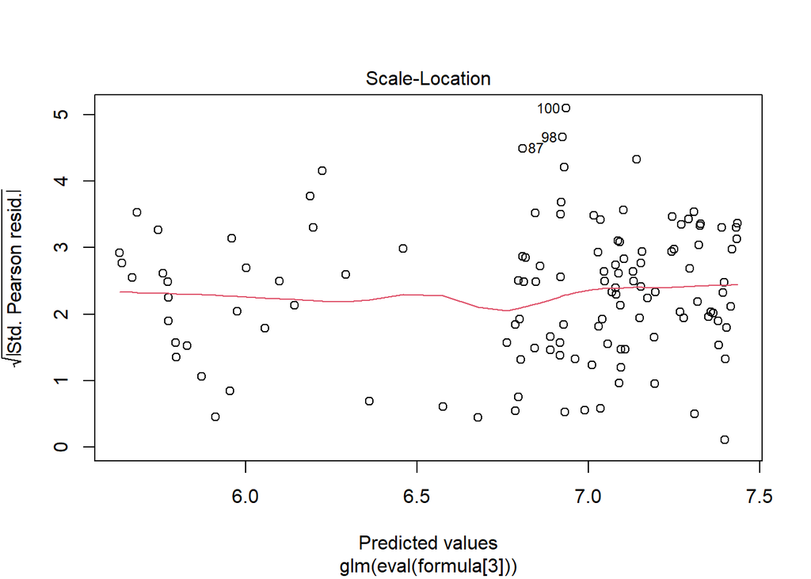

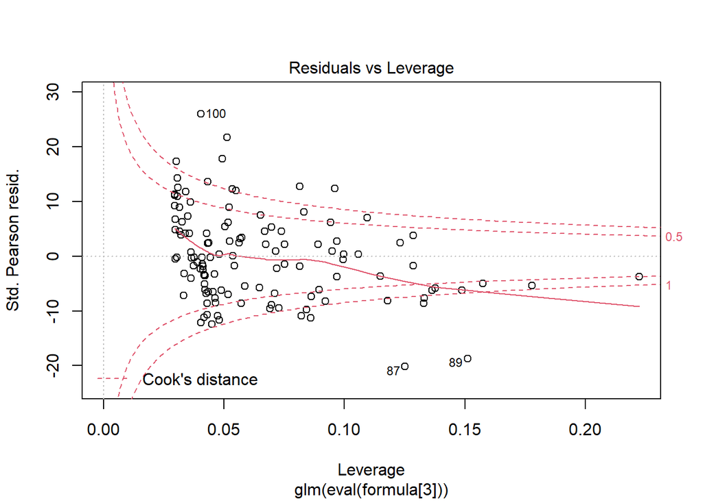

[4 more figures not shown]

```
##
## Call:
## glm(formula = eval(formula[5]), family = poisson(link = "log"),
##     data = df)
##
## Deviance Residuals:
##     Min       1Q   Median       3Q      Max
## -15.259   -4.931   -0.565    4.464   14.910
##
## Coefficients:
##                                      Estimate Std. Error z value Pr(>|z|)
## (Intercept)                         5.990e+00  4.581e-02 130.769  < 2e-16 ***
## ricoverati_con_sintomi              2.331e-04  3.147e-05   7.407 1.30e-13 ***
## nuovi_tamponi_pcr                   1.066e-04  3.486e-06  30.583  < 2e-16 ***
## colorbianco                        -1.238e+00  5.810e-02 -21.306  < 2e-16 ***
## colorgiallo                        -5.026e-01  7.005e-02  -7.175 7.25e-13 ***
## colorrosso                          2.890e-01  6.587e-02   4.388 1.14e-05 ***
## ricoverati_con_sintomi:colorbianco  1.488e-03  4.596e-05  32.373  < 2e-16 ***
## ricoverati_con_sintomi:colorgiallo  1.036e-05  5.391e-05   0.192 0.847573
## ricoverati_con_sintomi:colorrosso  -5.976e-04  6.171e-05  -9.684  < 2e-16 ***
## nuovi_tamponi_pcr:colorbianco      -4.435e-05  7.186e-06  -6.172 6.75e-10 ***
## nuovi_tamponi_pcr:colorgiallo       2.230e-05  6.179e-06   3.609 0.000307 ***
## nuovi_tamponi_pcr:colorrosso        3.098e-05  6.372e-06   4.862 1.16e-06 ***
## ---
## Signif. codes:  0 '***' 0.001 '**' 0.01 '*' 0.05 '.' 0.1 ' ' 1
##
## (Dispersion parameter for poisson family taken to be 1)
##
##     Null deviance: 30598.5  on 122  degrees of freedom
## Residual deviance:  5063.8  on 111  degrees of freedom
## AIC: 6150
##
## Number of Fisher Scoring iterations: 4
```

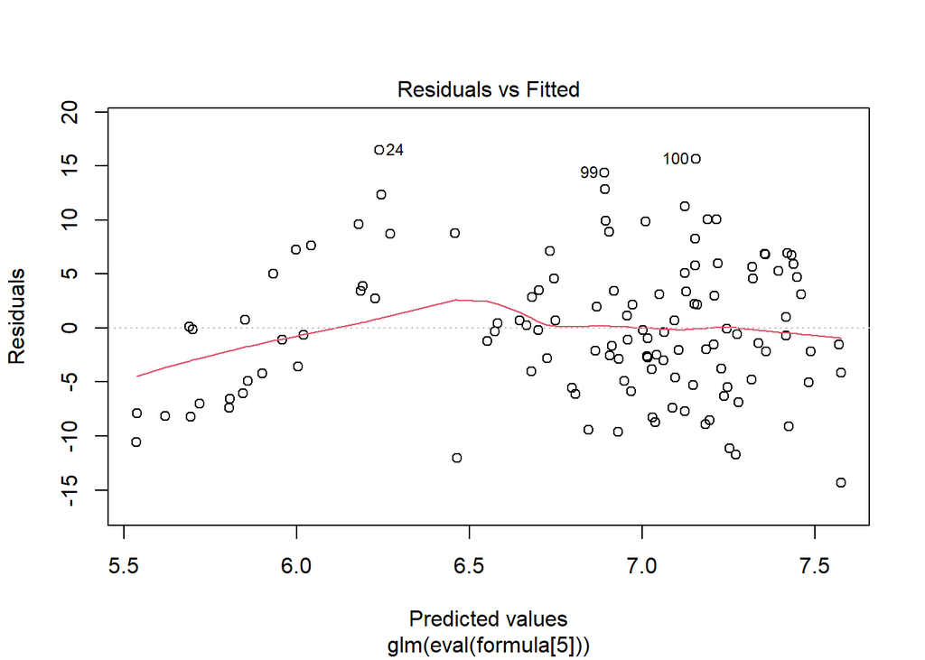

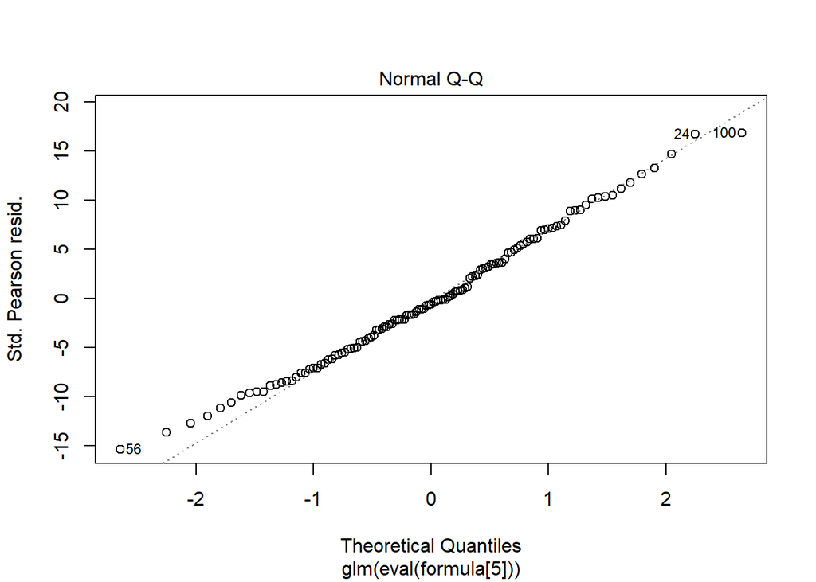

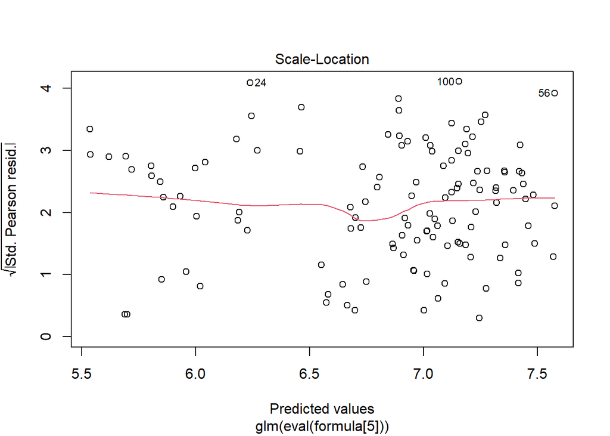

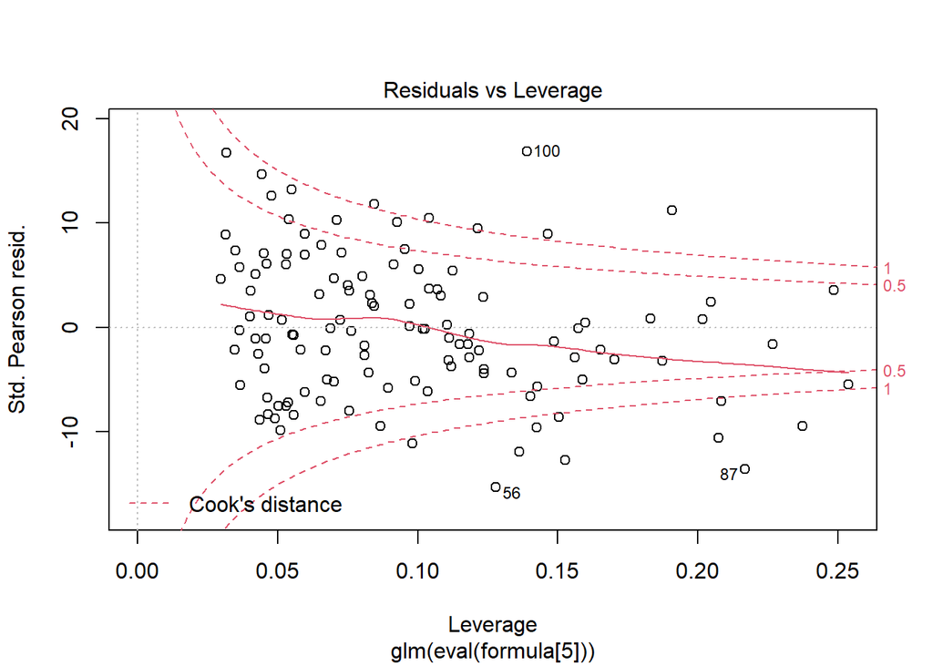

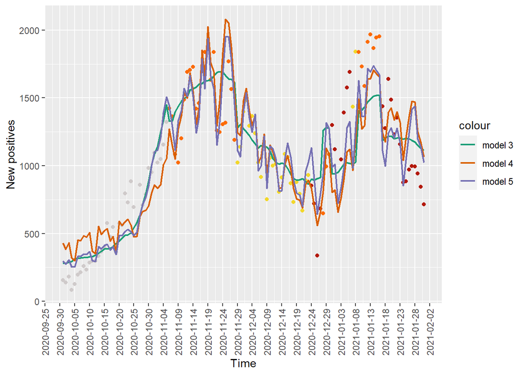

```
##          df       AIC
## glm_mod1  2 11485.561
## glm_mod2  5 10264.652
## glm_mod3  8  8549.686
## glm_mod4  6  8298.537
## glm_mod5 12  6149.989
```